# Lab8

## Exercise 1 - NGPhylogeny.fr

Use NGPhylogeny.fr to analysis the set of rRNA sequence provided. Describe the methods and put the .png file from your analysis into your Lab 8 .Rmd file

The methodology behind NGPhylogeny.fr includes multiple sequence alignment, phylogenetic analysis and the data output is tree visualization.

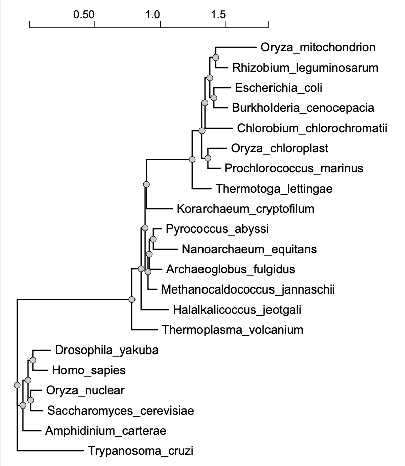

## Exercise 2 - CIPRES

Complete. Output files saved in data folder.

## Exercise 3 - ggTree Tutorial

Load libraries.

```r
library(tidyverse)
library(ggtree)
library(treeio)
```

```r
library(ggimage)
```

Exercise 1 Download the example tree and read it’s contents.

```r
tree <- read.tree("data/tree_newick.nwk")
tree
```

```
##
## Phylogenetic tree with 13 tips and 12 internal nodes.
##
## Tip labels:
##   A, B, C, D, E, F, ...
##
## Rooted; includes branch lengths.
```

Exercise 1 Create a slanted phylogenetic tree.

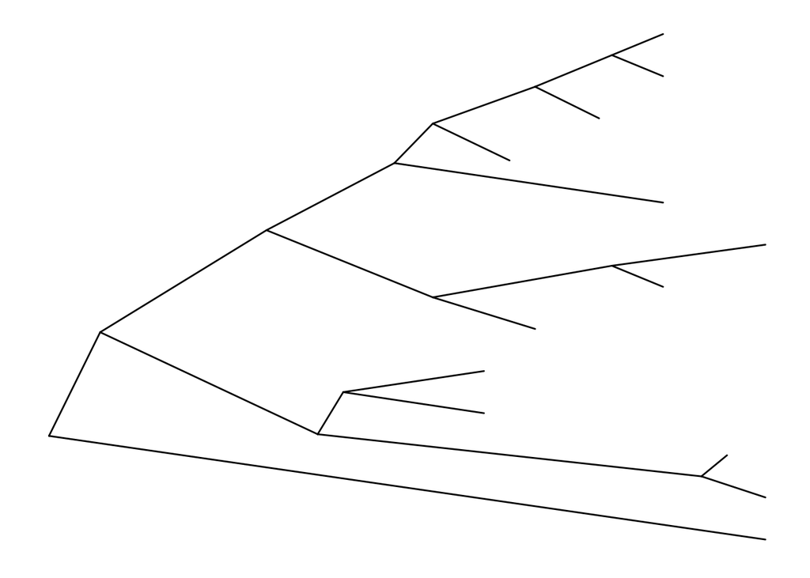

```r
#?ggtree
ggtree(tree, layout = "slanted")
```

Exercise 1 Create a circular phylogenetic tree.

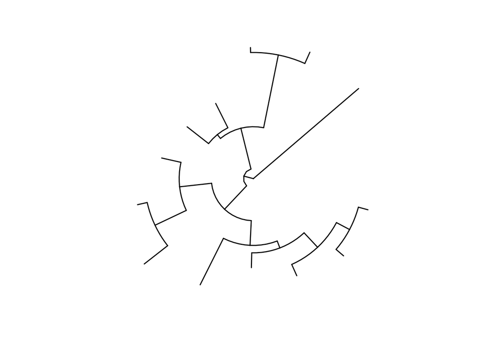

```r
ggtree(tree, layout = "circular")
```

Exercise 1 Create a circular unscaled cladogram with thick red lines.

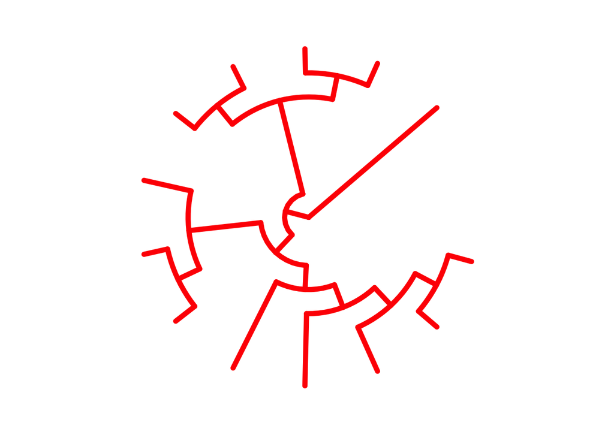

```r
ggtree(tree, layout = "circular", branch.length="none", color="red", size=2)
```

Exercise 2 Create a phylogeny with the following aesthetic characteristics: 1. tips labeled in purple 2. purple-colored diamond-shape tip points (hint: Google search “R point characters”) 3. large semitransparent yellow node points (hint: alpha=) 4. Add a title with + ggtitle(…)

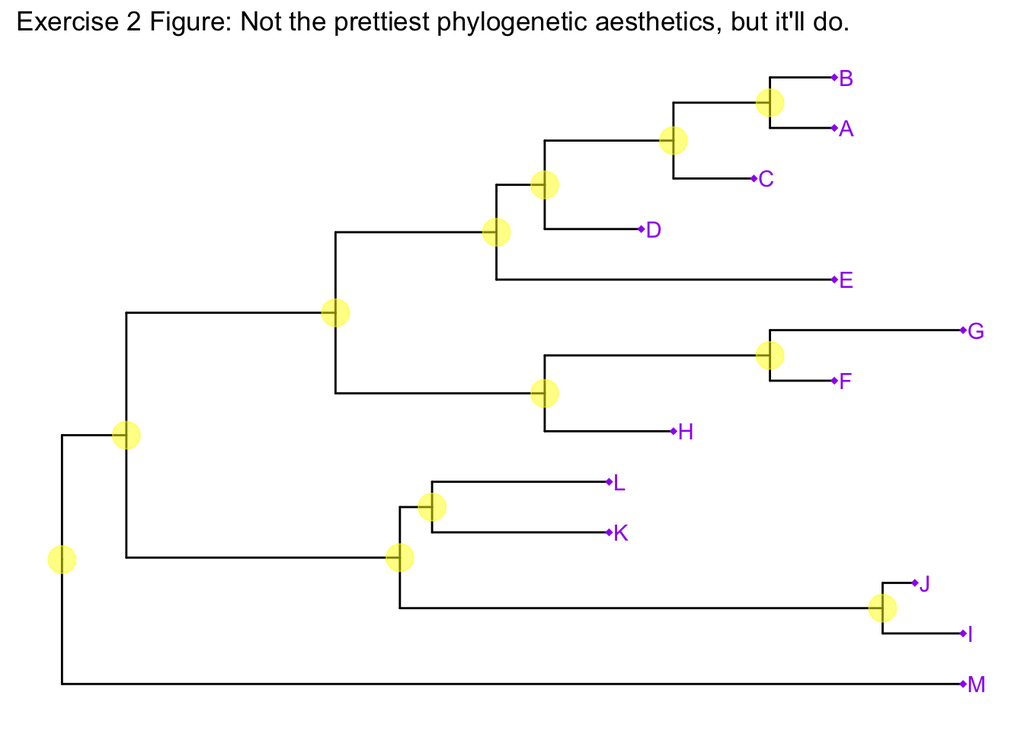

```r
p <- ggtree(tree)
p + geom_tippoint(color = "purple", pch = 18) + geom_tiplab(color = "purple") + geom_nodepoint(color="yellow", size=6, alpha = 0.5) + ggtitle("Exercise 2 Figure: Not the prettiest phylogenetic aesthetics, but it'll do.")
```

Exercise 3 1. First, find what the MRCA is for taxa B+C, and taxa L+J. 2. Draw the tree with ggtree(tree). 3. Add tip labels. 4. Highlight these clades with separate colors. 5. Add a clade label to the larger superclade (node=17) that we saw before that includes A, B, C, D, and E. 6. Link taxa C to E, and G to J with a dashed gray line. 7. Add a scale bar to the bottom by changing the theme. 8. Add a title.

```r
MRCA(tree, c("B", "C"))
```

```
## [1] 19
```

```r
MRCA(tree, c("L", "J"))
```

```
## [1] 23
```

[output not shown]

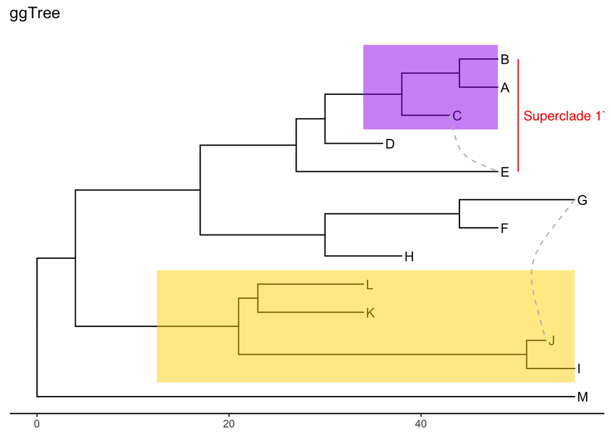

```r
ggtree(tree) +
  geom_tiplab() +
  geom_hilight(node=19, fill="purple") +
  geom_hilight(node=23, fill="gold") +
  geom_cladelabel(node=17, label="Superclade 17", color="red2", offset= -7, align=TRUE) +
  geom_taxalink("C", "E", color = "grey", linetype = 2) +
  geom_taxalink("G", "J", color = "grey", linetype = 2) +
  theme_tree2() +
  ggtitle("ggTree")
```

9. Optionally, go back to the original ggtree(tree, …) call and change the layout to “circular”.

[output not shown]

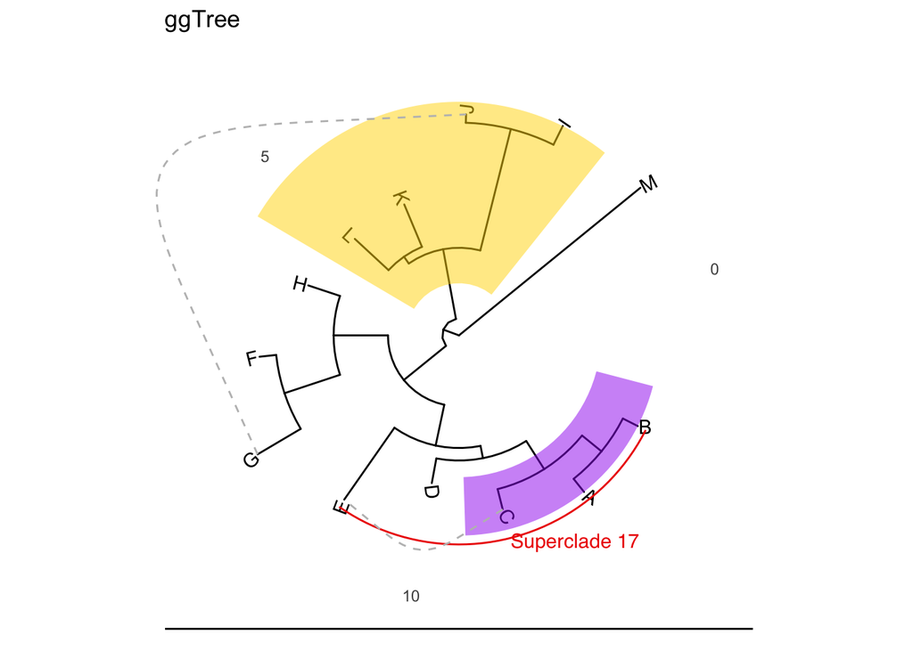

```r
ggtree(tree, layout = "circular") +
  geom_tiplab() +
  geom_hilight(node=19, fill="purple") +
  geom_hilight(node=23, fill="gold") +
  geom_cladelabel(node=17, label="Superclade 17", color="red2", offset= -7, align=TRUE) +
  geom_taxalink("C", "E", color = "grey", linetype = 2) +
  geom_taxalink("G", "J", color = "grey", linetype = 2) +
  theme_tree2() +
  ggtitle("ggTree")
```

Bonus

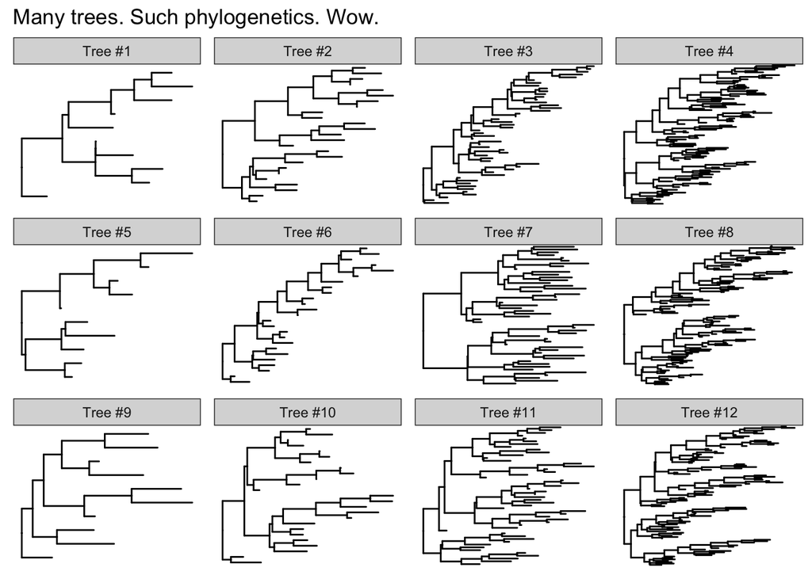

```r
set.seed(42)
trees <- lapply(rep(c(10, 25, 50, 100), 3), rtree)
class(trees) <- "multiPhylo"
ggtree(trees) + facet_wrap(~.id, scale="free", ncol=4) + ggtitle("Many trees. Such phylogenetics. Wow.")
```

## Exercise 4 - Using ggtree with the FastTreeMP output file on CIPRES

Coloring the tree according to the domains of life.

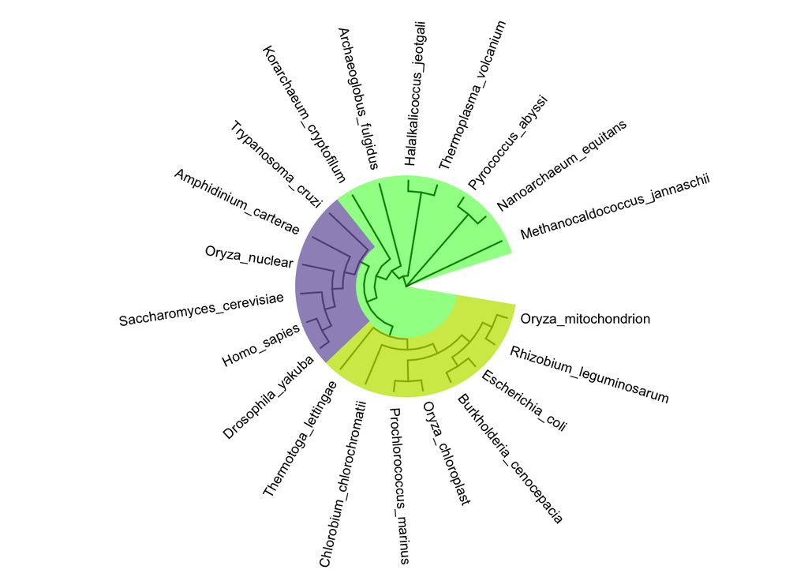

```r
my_tree <- read.tree("data/fastree_result.tre")

ggtree(my_tree, branch.length="none", layout = "circular") +
  xlim(0,21) +
  geom_tiplab(hjust=-.1, size = 3) +
  geom_hilight(node=22, fill="green", extend = 0.5) +
  geom_hilight(node=34, fill="gold", extend = 0.5) +
  geom_hilight(node=29, fill="purple", extend = 0.5)
```